# Analysis

Aemro Chanie

2022-08-07

```r
# Load the appropriate libraries that can be used to analyse the data
library(tidyverse)
```

```r
library(ggplot2)
library(vtable)
library(fixest)
library(jtools)
```

# Introduction

Research Question: The College Scorecard was released at the start of September 2015. Among colleges that predominantly grant bachelor’s degrees, did the release of the Scorecard shift student interest to high-earnings colleges relative to low-earnings ones (as proxied by Google searches for keywords associated with those colleges)?

To answer this question, I have to pull Google trend data, school scorecard data and the ID_name link data and clean the data. Finally merge and selects columns that i feel are relevant for the data analysis portion of this study. corecard data set will include only primarily bachelor’s degree granting schools. Other NULL values or cells with unavailable data are also filtered out. Variables are characterized accordingly. The variables filtered and included from the Scorecard data are: unitid and opeid (for joining to Google data), STABBR (state), PREDDEG (primarily bachelor’s degree schools), LOCALE (size of local area surrounding school; i.e. city, suburban, rural), CONTROL (public vs. private vs. non-profit), HBCU (historically black colleges), MENONLY, WOMENONLY, PBI (predominantly black institute), HSI (hispanic serving institution), and MED_EARNINGS (median earnings of students post grad).

```r
clean_df <- read_csv("../raw_data/clean_df.csv")
```

Below I used ggplot to determine if my data is normally distributed. As you can see, it looks like there are some problems in my data given the shape. One reason might be there is an outliers data that affected the relationship or the relationship is not linear. To minimize the skewness of the graph, using the log linear function is been used below.

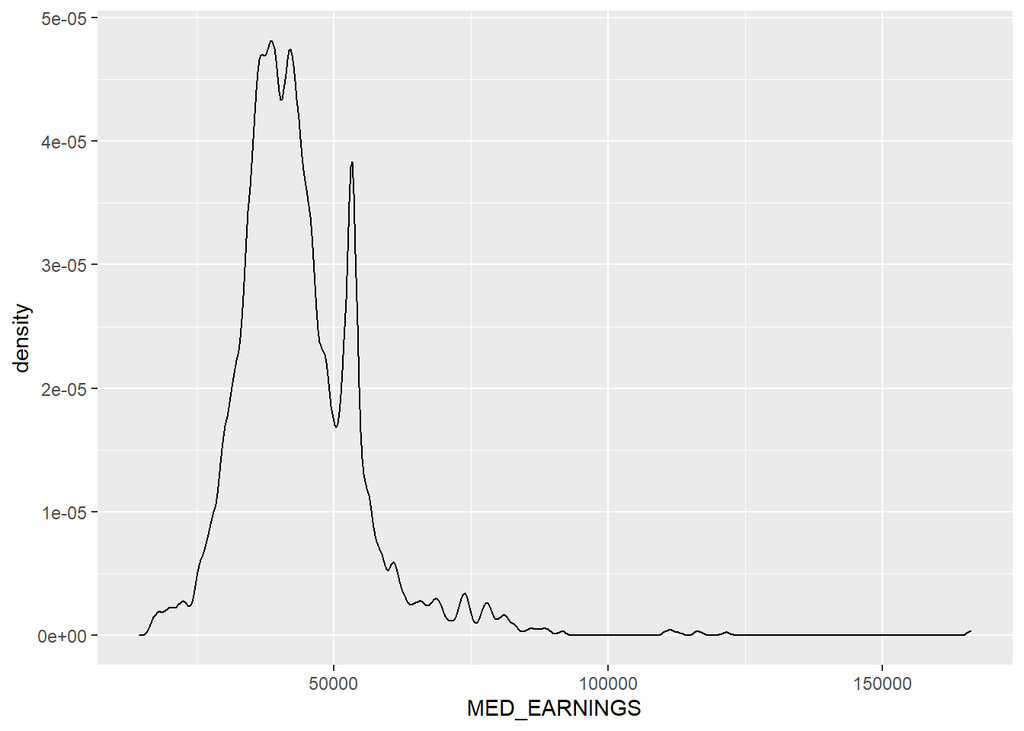

```r
ggplot(clean_df, aes(x= MED_EARNINGS)) + geom_density()
```

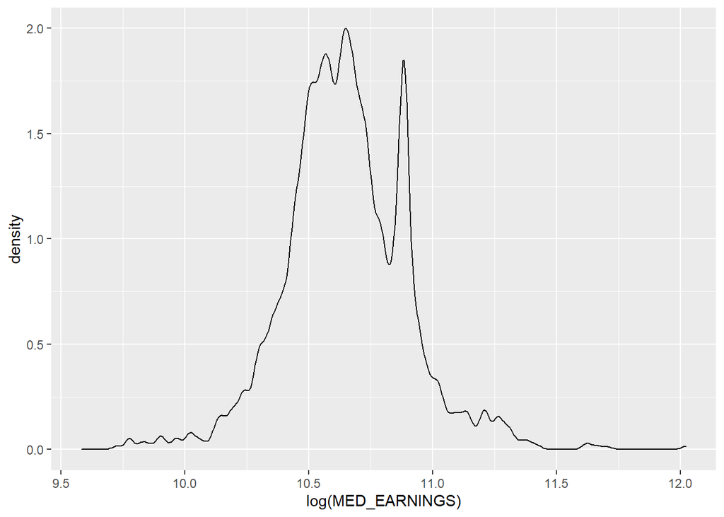

```r
# log of the median income was taken to avoid right skewness of the data on the graph. Though the skewness has been removed, there seem to be an outier data that still cause heteroskedasticity

ggplot(clean_df, aes(x= log(MED_EARNINGS))) + geom_density()
```

Before running regressions, we must first distinguish our cutoff for “High-Earning” vs. “Low-Earning” colleges. To do this, I used the median income from the given data which turns out to be $41800. So my analysis moving forward will have the logic that schools with median earnings for alumni 10 years after graduation above $41,800 will be considered as ‘high earning schools’ while those below $41,800 will be considered as ‘low earning schools’.

```r
#
median(clean_df$`MED_EARNINGS`)
```

```
## [1] 41800
```

```r
final_df <- clean_df %>%
  mutate(high_earning = MED_EARNINGS > 41800)
```

```r
m1 <- feols(index_std ~ after_2015 * high_earning, data = final_df)
```

```
## NOTE: 49 observations removed because of NA values (LHS: 49, RHS: 49).
```

```r
etable(m1, vcov = 'hetero')
```

```
##                                                    m1
## Dependent Var.:                             index_std
##
## (Intercept)                        0.0440*** (0.0032)
## after_2015TRUE                    -0.2716*** (0.0084)
## high_earningTRUE                      0.0062 (0.0046)
## after_2015TRUE x high_earningTRUE  -0.0377** (0.0117)
## _________________________________ ___________________
## S.E. type                         Heteroskedast.-rob.
## Observations                                  212,567
## R2                                            0.01181
## Adj. R2                                       0.01180
## ---
## Signif. codes: 0 '***' 0.001 '**' 0.01 '*' 0.05 '.' 0.1 ' ' 1
```

```r
m2 <- feols(index_std ~ after_2015*high_earning + Season, data = final_df)
```

```
## NOTE: 49 observations removed because of NA values (LHS: 49, RHS: 49).
```

```r
m3 <- feols(index_std ~ after_2015*high_earning | Season, data = final_df)
```

```
## NOTE: 49 observations removed because of NA values (LHS: 49, RHS: 49, Fixed-effects: 49).
```

```r
m4 <- feols(index_std ~ after_2015*high_earning | month, data = final_df)
```

```
## NOTE: 49 observations removed because of NA values (LHS: 49, RHS: 49, Fixed-effects: 49).
```

```
## The variable 'after_2015TRUE' has been removed because of collinearity (see $collin.var).
```

```r
# Regressions side by side
etable(m1, m2, m3, m4)
```

```
##                                                    m1                  m2
## Dependent Var.:                             index_std           index_std
##
## (Intercept)                        0.0440*** (0.0033)  0.4162*** (0.0049)
## after_2015TRUE                    -0.2716*** (0.0081) -0.2971*** (0.0082)
## high_earningTRUE                      0.0062 (0.0046)     0.0067 (0.0045)
## after_2015TRUE x high_earningTRUE  -0.0377** (0.0115) -0.0372*** (0.0113)
## SeasonSpring                                          -0.5211*** (0.0059)
## SeasonSummer                                          -0.4181*** (0.0061)
## SeasonWinter                                          -0.5253*** (0.0059)
## Fixed-Effects:                    ------------------- -------------------
## Season                                             No                  No
## month                                              No                  No
## _________________________________ ___________________ ___________________
## S.E. type                                         IID                 IID
## Observations                                  212,567             212,567
## R2                                            0.01181             0.05922
## Within R2                                          --                  --
##
##                                                  m3                m4
## Dependent Var.:                           index_std         index_std
##
## (Intercept)
## after_2015TRUE                    -0.2971. (0.1234)
## high_earningTRUE                    0.0067 (0.0143)   0.0142 (0.0154)
## after_2015TRUE x high_earningTRUE  -0.0372 (0.0170) -0.0424. (0.0233)
## SeasonSpring
## SeasonSummer
## SeasonWinter
## Fixed-Effects:                    ----------------- -----------------
## Season                                          Yes                No
## month                                            No               Yes
## _________________________________ _________________ _________________
## S.E. type                                by: Season         by: month
## Observations                                212,567           212,567
## R2                                          0.05922           0.44143
## Within R2                                   0.01295           0.00014
## ---
## Signif. codes: 0 '***' 0.001 '**' 0.01 '*' 0.05 '.' 0.1 ' ' 1
```

The regression models two and three utilize season as a control, being different in the linear model versus fixed effects. Model four uses fixed effects on the month.

```r
# Additional regression controls (showed no impact)
m5 <- feols(index_std ~ after_2015*high_earning + HBCU, data = final_df)
```

```
## NOTE: 49 observations removed because of NA values (LHS: 49, RHS: 49).
```

```r
m6 <- feols(index_std ~ after_2015*high_earning + MENONLY, data = final_df)
```

```
## NOTE: 49 observations removed because of NA values (LHS: 49, RHS: 49).
```

```r
m7 <- feols(index_std ~ after_2015*high_earning + LOCALE, data = final_df)
```

```
## NOTE: 49 observations removed because of NA values (LHS: 49, RHS: 49).
```

```r
etable(m5, m6, m7)
```

```
##                                                    m5                  m6
## Dependent Var.:                             index_std           index_std
##
## (Intercept)                        0.0440*** (0.0034)  0.0440*** (0.0033)
## after_2015TRUE                    -0.2716*** (0.0081) -0.2716*** (0.0081)
## high_earningTRUE                      0.0062 (0.0047)     0.0062 (0.0046)
## HBCU                                 -0.0002 (0.0106)
## after_2015TRUE x high_earningTRUE  -0.0377** (0.0115)  -0.0377** (0.0115)
## MENONLY                                                   0.0010 (0.0471)
## LOCALE
## _________________________________ ___________________ ___________________
## S.E. type                                         IID                 IID
## Observations                                  212,567             212,567
## R2                                            0.01181             0.01181
## Adj. R2                                       0.01179             0.01179
##
##                                                    m7
## Dependent Var.:                             index_std
##
## (Intercept)                        0.0438*** (0.0061)
## after_2015TRUE                    -0.2716*** (0.0081)
## high_earningTRUE                      0.0062 (0.0048)
## HBCU
## after_2015TRUE x high_earningTRUE  -0.0377** (0.0115)
## MENONLY
## LOCALE                               6.78e-6 (0.0002)
## _________________________________ ___________________
## S.E. type                                         IID
## Observations                                  212,567
## R2                                            0.01181
## Adj. R2                                       0.01179
## ---
## Signif. codes: 0 '***' 0.001 '**' 0.01 '*' 0.05 '.' 0.1 ' ' 1
```

```r
# Season seems to be the only variable that we should control for to capture the effect.
```

The additional controls added in models 5, 6, and 7, have no strong influence on the model and do not improve it.

```r
# Consolidation of standardized index scores to be one record per month
final_df <- final_df %>%
  group_by(month, high_earning) %>%
  summarize(index_std = mean(index_std, na.rm = TRUE))
```

[figure not shown]

```r
ggplot() +
  geom_line(data = final_df, aes(x = month, y = index_std, color = high_earning)) +
  scale_x_date(breaks = scales :: breaks_pretty(13)) +
  geom_vline(xintercept = as.Date("2015-09-01")) +
  theme(panel.grid.major = element_blank(), panel.grid.minor = element_blank(),
        panel.background = element_blank(), axis.line = element_line(colour = "black")) +
  labs(title = "Google Index Score Averages Per Month",
       subtitle = "Distinguished by High Earning vs. Low Earning University",
       x = "Date", y = "Mean Standard Deviation of Index Score")
```

## Conclusion

As it was diplayed in the model the controlling for the season variable does not change much on the standard deviation thus we can fairly conclude that students interest was low income earning schools as compareed to the high income earning schools.